# WorMotel lifespan Heritability

Tim C.

5/29/2018

This code uses processed survival data from Chris Fang-Yen’s lab to calculate heritability of survival traits. The data were collected with WorMotel in four replicate blocks by Matt Churgin at UPenn. Four independent bleaches of 12 strains (blocks) were run on 2-4 replicate wormmotels (20 nematodes / strain).

## Trait heritability (all blocks)

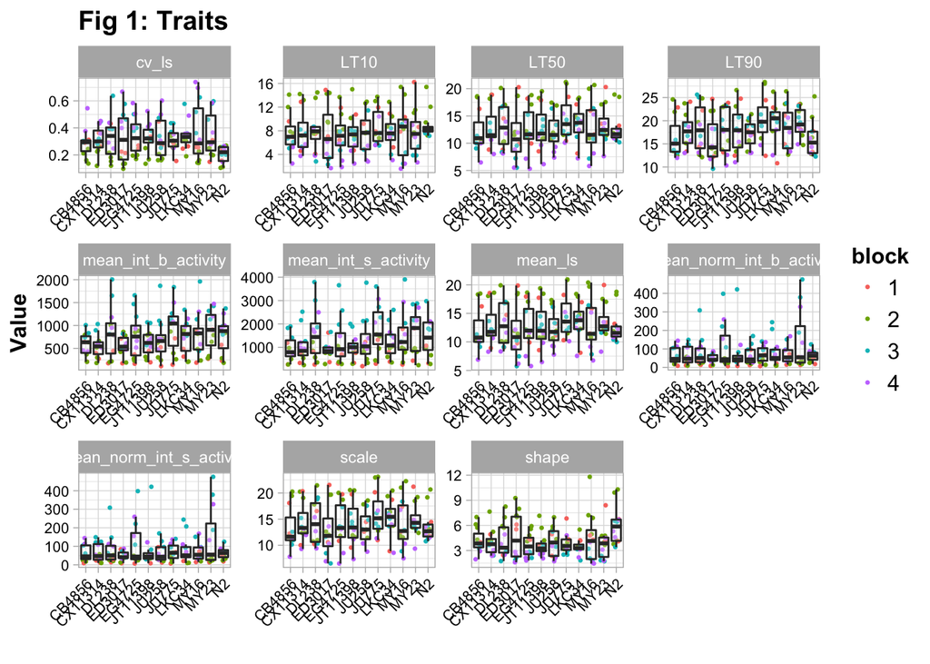

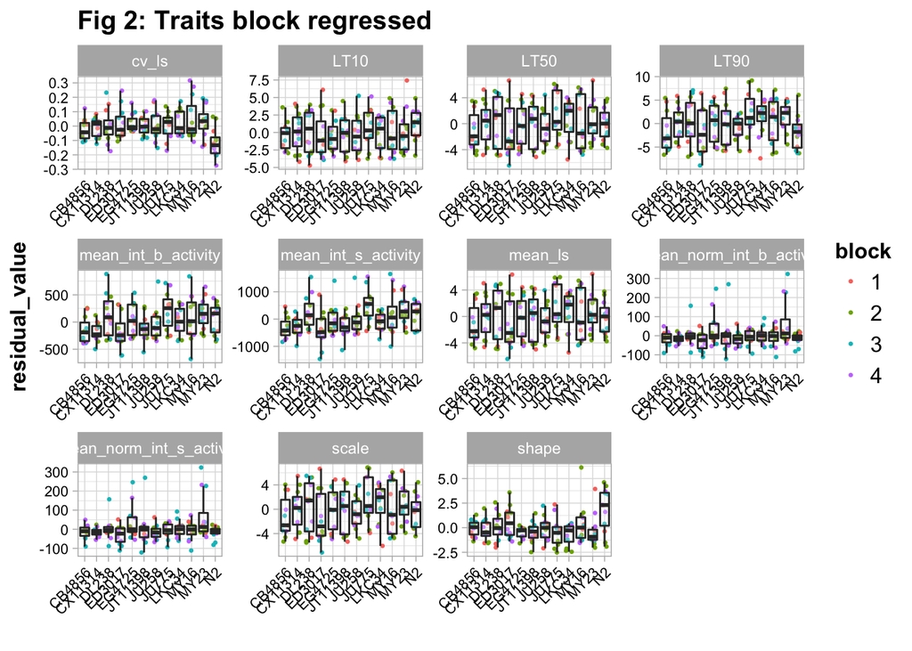

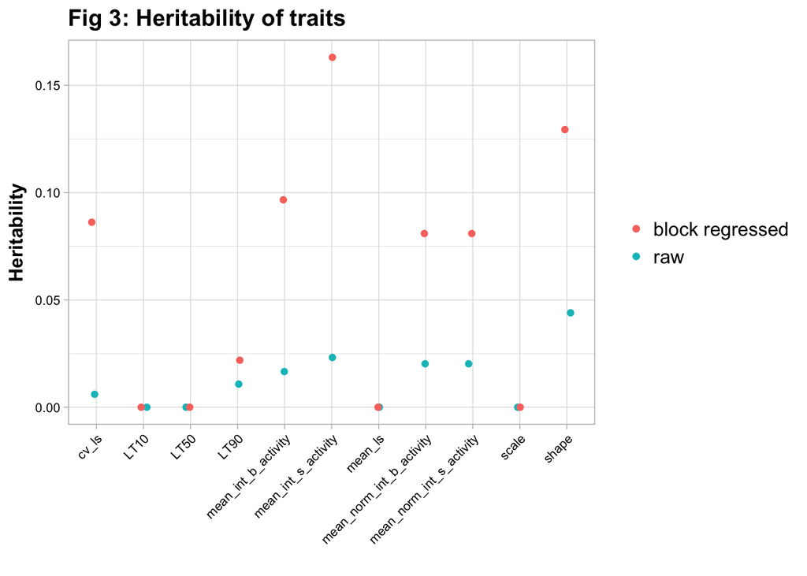

`cv_ls` = coefficient of variation for lifespan  
`LT10` = time to 10% death  
`LT50` = time to 50% death  
`LT90` = time to 90% death  
`mean_int_b_activity` = mean integrated base activity  
`mean_int_s_activity` = mean integrated stimulated activity  
`mean_ls = mean lifespan`  
`mean_norm_int_b_activity` = mean integrated base activity / mean lifespan  
`mean_norm_int_s_activity` = mean integrated stimulated activity / mean lifespan  
`scale` = survival fit parameter  
`shape` = survival fit parameter

## Trait heritability (blocks 3 and 4 only)

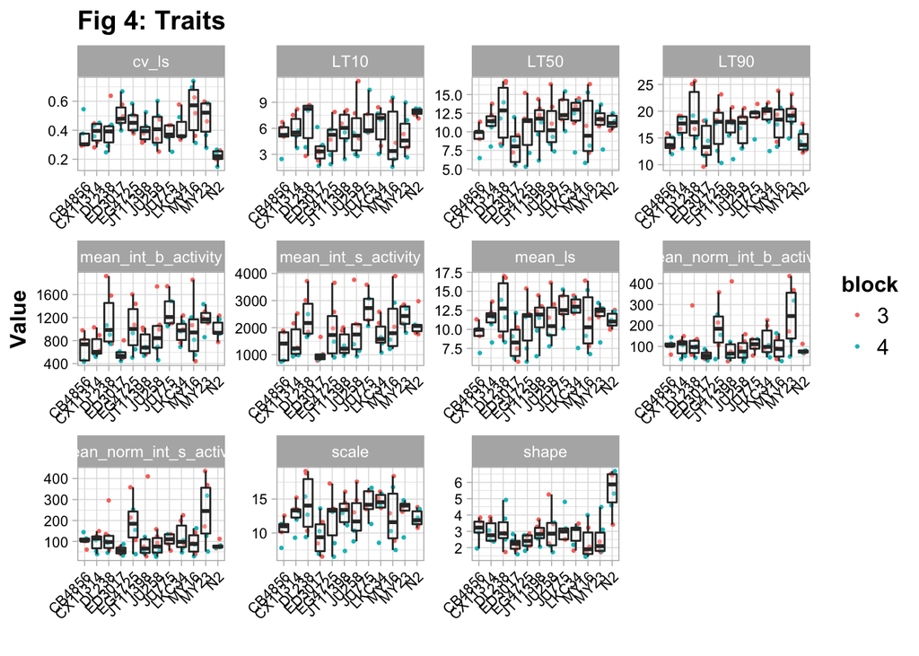

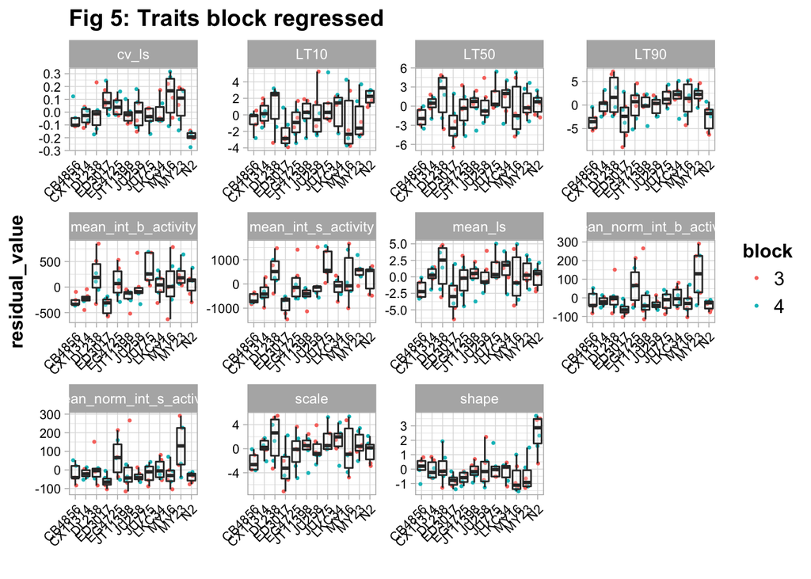

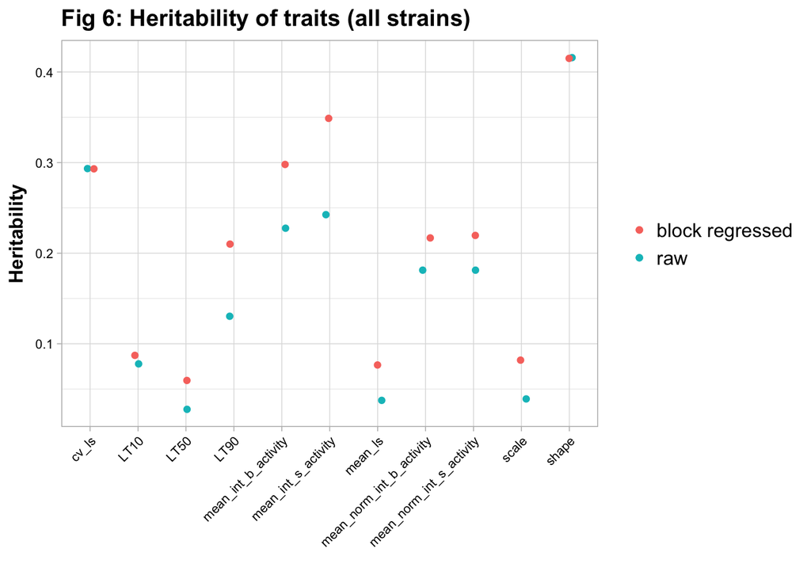

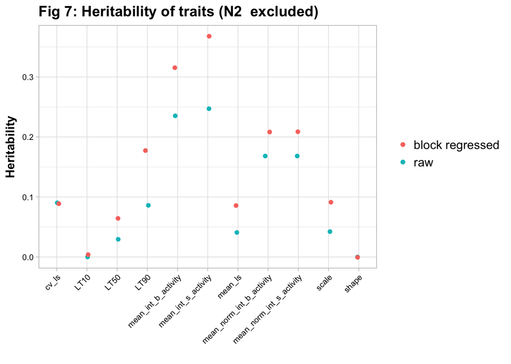

1) Restricting analysis to new data only results in higher H2 values (Fig. 3 vs. Fig. 6).  
2) N2 is driving the high heritability of `cv_ls` and `shape` traits (Fig. 6 vs. Fig. 7).  
3) JU775 and DL238 have high integrated activity traits (Fig. 5). This is consistent with observations in the past.  
4) How can we best normalize activity traits to capture healthspan? Normalization by mean_lifespan seems odd.

## Subsampling within blocks

Randomly subsample a single worMotel for each block 10 times and calculate H2 w/ block regression.

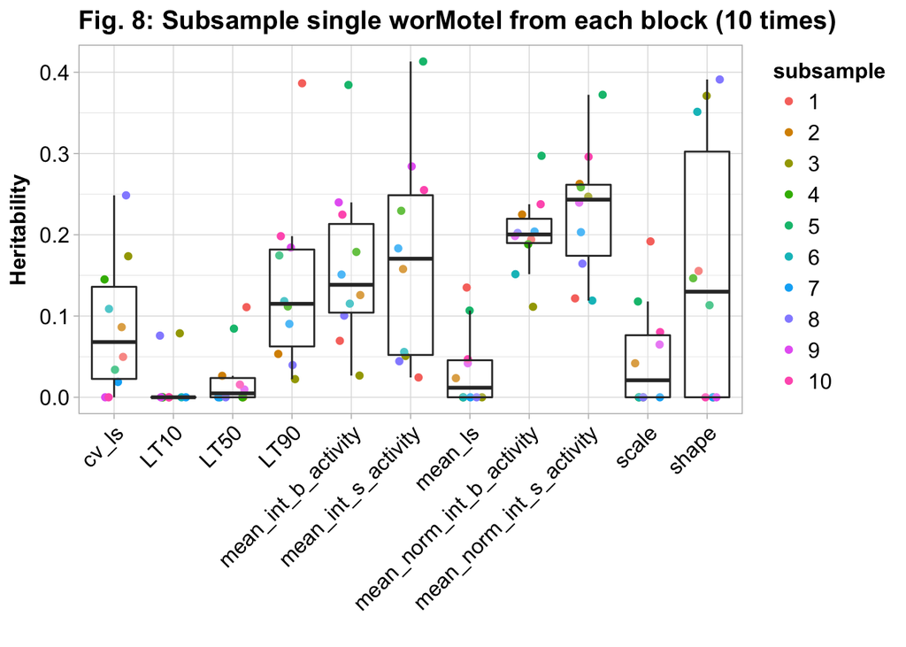

1) Are we better off with a single worMotel per block?  
2) Other subsampling strategies? Inference for each?

## 24-well Assay

These data are from 24-well plates not worMotels. I believe 20 L4 nematodes were added to each well; there are two replicate wells for each strain in a block.  
**lifespan** = This is an estimate based on 2% of total stimulated activity remaining in a particular well.  
**healthspan** = Similar to lifespan but for base activity?

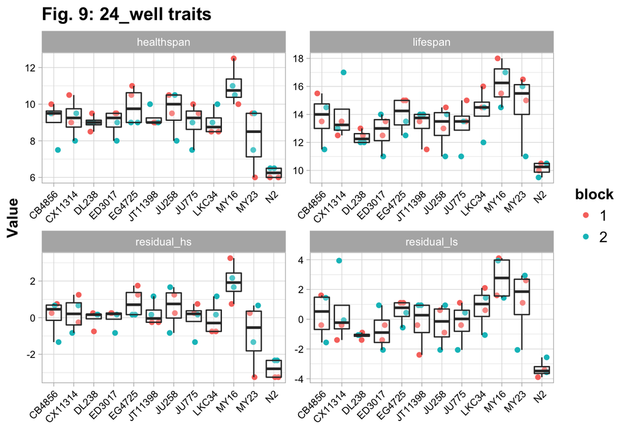

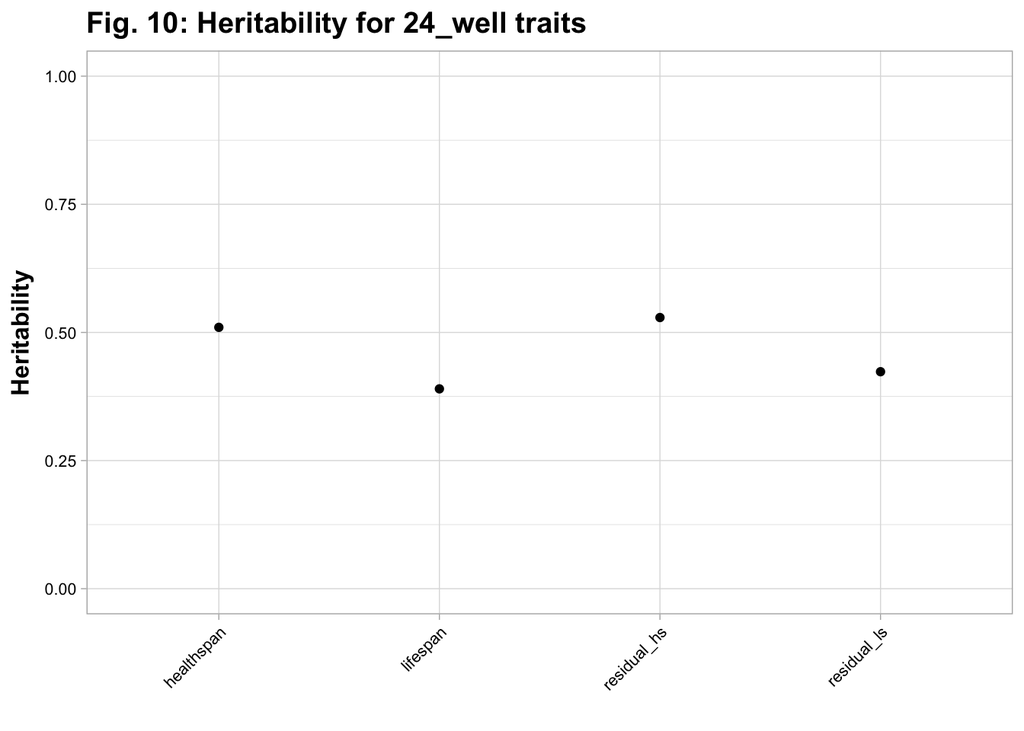

1) Heritability is HIGH for lifespan and healthspan!  
2) Very small block effect, regressing out this effect does not improve heritability by much.  
3) How well do these values relate to actual lifespan? How much does that matter?